# Введение в dplyr[*](http://cran.rstudio.com/web/packages/dplyr/vignettes/introduction.html)

При обработке данных вы должны:

- Представить что вы хотите получить.
- Детально описать желаемое в виде компьютерной программы.
- Выполнить код.

Пакет `dplyr` делает каждый из этих шагов на столько простым и быстрым на сколько это возможно следующим образом:

- Выделяя наиболее общие операции манипулирования данными, которые позволяют вам сосредоточиться на решении задачи, а не на манипулировании.
- Предлагая набор простых функций, соответствующих наиболее общим атомарным операциям манипулирования данными, так чтобы замысел максимально легко был выражен в коде.
- Используя эффективные хранилища данных чтобы максимально сократить время ожидания результата.

Цель этого документа – дать представление о базовых инструментах предоставляемых `dplyr`, и продемонстрировать их применение к структурам данных типа `data.frame`. Также существуют отдельные руководства по следующим темам:

- `databases`[*](http://cran.rstudio.com/web/packages/dplyr/vignettes/databases.html): наравне с объектами в памяти `dplyr` также может обращаться к данным баз данных. Это позволяет вам работать с удалёнными (в смысле нахождения на расстоянии) данными, используя в точности те же инструменты, потому что `dplyr` будет транслировать ваш код на R в соответствующие SQL-запросы.
- `benchmark-baseball`: рассматривает как `dplyr` выглядит в сравнении с другими инструментами для манипулирования данными на реалистичной задаче.
- `window-functions`[*](http://cran.rstudio.com/web/packages/dplyr/vignettes/window-functions.html): функции агрегирования по окну – это разновидность функций агрегирования, где функция агрегирования вычисляет по n аргументам 1 значение, а функции агрегирования по окну получает n аргументов и возвращает n значений.

## Набор данных nycflights13

Для исследования основных операций манипулирования данными в `dplyr` мы будем использовать встроенный набор данных `nycflights13`. Он содержит данные всех 336776 рейсов из Нью Йорка за 2013 год, и предоставлен, как написано в `?nycflights13`, [бюро по перемещениям США](http://www.transtats.bts.gov/DatabaseInfo.asp?DB_ID=120&Link=0).

```r
library(nycflights13)
dim(flights)
```

```
#> [1] 336776     16
```

```r
head(flights)
```

```
#> Source: local data frame [6 x 16]
#>
#>    year month day dep_time dep_delay arr_time arr_delay carrier tailnum
#> 1  2013     1   1      517         2      830        11      UA  N14228
#> 2  2013     1   1      533         4      850        20      UA  N24211
#> 3  2013     1   1      542         2      923        33      AA  N619AA
#> 4  2013     1   1      544        -1     1004       -18      B6  N804JB
#> ..  ...   ... ...      ...       ...      ...       ...     ...     ...
#> Variables not shown: flight (int), origin (chr), dest (chr), air_time
#>   (dbl), distance (dbl), hour (dbl), minute (dbl)
```

`dplyr` может работать с `data.frame` непосредственно, но при работе с большими объёмами данных стоит конвертировать их в `tbl_df`, обёртку вокруг `data.frame` которая не станет по случайности выводить кучу данных на экран (это может очень медленным процессом).

## Операции манипулирующие одной таблицей

Dplyr ставит своей целью дать функции для всех основных пераций манипулирования данным:

- `filter()` (и `slice()`)
- `arrange()`
- `select()` (и `rename()`)
- `distinct()`
- `mutate()` (и `transmute()`)
- `summarise()`
- `sample_n()` и `sample_frac()`

Для тех кто пользовался до этого `plyr` многие из них будут знакомы.

### Фильтрация строк при помощи filter()

`filter()` позволяет вам выбрать подмножество строк из `data.frame`. Первый аргумент – имя набора данных, второй и последующие – условия фильтра в контексте этого набора данных.

Например, мы можем выбрать все вылет 1-го января следующим образом:

```r
filter(flights, month == 1, day == 1)
```

```
#> Source: local data frame [842 x 16]
#>
#>    year month day dep_time dep_delay arr_time arr_delay carrier tailnum
#> 1  2013     1   1      517         2      830        11      UA  N14228
#> 2  2013     1   1      533         4      850        20      UA  N24211
#> 3  2013     1   1      542         2      923        33      AA  N619AA
#> 4  2013     1   1      544        -1     1004       -18      B6  N804JB
#> ..  ...   ... ...      ...       ...      ...       ...     ...     ...
#> Variables not shown: flight (int), origin (chr), dest (chr), air_time
#>   (dbl), distance (dbl), hour (dbl), minute (dbl)
```

```r
flights[flights$month == 1 & flights$day == 1, ]
```

`filter()` работает аналогично `subset()` за тем исключением, что вы можете ему передать любое количество условий для фильтра, которые будут объединены вместе через `&` (логическое И, но не `&&` с которым можно случайно перепутать). Вы можете также использовать любые другие логически связки:

```r
filter(flights, month == 1 | month == 2)
```

Для выборки строк по позициям используется `slice()`:

```r
slice(flights, 1:10)
```

```
#> Source: local data frame [10 x 16]
#>
#>    year month day dep_time dep_delay arr_time arr_delay carrier tailnum
#> 1  2013     1   1      517         2      830        11      UA  N14228
#> 2  2013     1   1      533         4      850        20      UA  N24211
#> 3  2013     1   1      542         2      923        33      AA  N619AA
#> 4  2013     1   1      544        -1     1004       -18      B6  N804JB
#> ..  ...   ... ...      ...       ...      ...       ...     ...     ...
#> Variables not shown: flight (int), origin (chr), dest (chr), air_time
#>   (dbl), distance (dbl), hour (dbl), minute (dbl)
```

### Упорядочение строк при помощи arrange()

`arrange()`, в свою очередь, работает аналогично `filter()` за исключением того, что вместо выбора строк она переупорядочивает их. Функция получает на вход имя таблицы данных и список имён колонок (или более сложное выражение) для упорядочения по ним. Если будет указано больше одной колонки, то каждая следующая колонка будет упорядочиваться в пределах каждого отдельного набора значений предыдущих:

```r
arrange(flights, year, month, day)
```

```
#> Source: local data frame [336,776 x 16]
#>
#>    year month day dep_time dep_delay arr_time arr_delay carrier tailnum
#> 1  2013     1   1      517         2      830        11      UA  N14228
#> 2  2013     1   1      533         4      850        20      UA  N24211
#> 3  2013     1   1      542         2      923        33      AA  N619AA
#> 4  2013     1   1      544        -1     1004       -18      B6  N804JB
#> ..  ...   ... ...      ...       ...      ...       ...     ...     ...
#> Variables not shown: flight (int), origin (chr), dest (chr), air_time
#>   (dbl), distance (dbl), hour (dbl), minute (dbl)
```

Необходимо использовать `desc()` чтобы задать порядок по убыванию:

```r
arrange(flights, desc(arr_delay))
```

```
#> Source: local data frame [336,776 x 16]
#>
#>    year month day dep_time dep_delay arr_time arr_delay carrier tailnum
#> 1  2013     1   9      641      1301     1242      1272      HA  N384HA
#> 2  2013     6  15     1432      1137     1607      1127      MQ  N504MQ
#> 3  2013     1  10     1121      1126     1239      1109      MQ  N517MQ
#> 4  2013     9  20     1139      1014     1457      1007      AA  N338AA
#> ..  ...   ... ...      ...       ...      ...       ...     ...     ...
#> Variables not shown: flight (int), origin (chr), dest (chr), air_time
#>   (dbl), distance (dbl), hour (dbl), minute (dbl)
```

`dplyr::arrange()` работает так же как и `plyr::arrange()`. Это простая обёртка над `order()`, только позволяющая меньше набирать на клавиатуре. Предыдущий пример эквивалентен такому выражению:

```r
flights[order(flights$year, flights$month, flights$day), ]
flights[order(desc(flights$arr_delay)), ]
```

### Выбор колонок при помощи select()

Часто случается что при работе с большим набором данных вам на самом деле интересны только некоторые колонки. `select()` позволяет вам быстро сфокусироваться на интересующей части колонок, используя при этом символические имена на манер номеров колонок:

```r
# Select columns by name
select(flights, year, month, day)
```

```
#> Source: local data frame [336,776 x 3]
#>
#>    year month day
#> 1  2013     1   1
#> 2  2013     1   1
#> 3  2013     1   1
#> 4  2013     1   1
#> ..  ...   ... ...
```

```r
# Select all columns between year and day (inclusive)
select(flights, year:day)
```

```
#> Source: local data frame [336,776 x 3]
#>
#>    year month day
#> 1  2013     1   1
#> 2  2013     1   1
#> 3  2013     1   1
#> 4  2013     1   1
#> ..  ...   ... ...
```

```r
# Select all columns except those from year to day (inclusive)
select(flights, -(year:day))
```

```
#> Source: local data frame [336,776 x 13]
#>
#>    dep_time dep_delay arr_time arr_delay carrier tailnum flight origin
#> 1       517         2      830        11      UA  N14228   1545    EWR
#> 2       533         4      850        20      UA  N24211   1714    LGA
#> 3       542         2      923        33      AA  N619AA   1141    JFK
#> 4       544        -1     1004       -18      B6  N804JB    725    JFK
#> ..      ...       ...      ...       ...     ...     ...    ...    ...
#>    dest
#> 1   IAH
#> 2   IAH
#> 3   MIA
#> 4   BQN
#> ..  ...
#> Variables not shown: air_time (dbl), distance (dbl), hour (dbl), minute
#>   (dbl)
```

Эта функция работает подобно аргументу `select` в `base::subset()`. Отдельная функция добавлена для поддержания стройности идеологии `dplyr`, заключающейся в наличии функций каждая из которых делает только одну конкретную операцию и наиболее подходящим образом.

С `select()` используется ряд вспомогательных, такие как `starts_with()`, `ends_with()`, `matches()` и `contains()`. Они упрощают получение больших блоков колонок которые удовлетворяют некоторому критерию. Для получения подробностей смотрите `?select`.

При помощи `select()` вы можете переименовывать колонки используя именованные аргументы:

```r
select(flights, tail_num = tailnum)
```

```
#> Source: local data frame [336,776 x 1]
#>
#>    tail_num
#> 1    N14228
#> 2    N24211
#> 3    N619AA
#> 4    N804JB
#> ..      ...
```

Но поскольку она отбрасывает все явно не указанные аргументы, используйте вместо неё для этого `rename()`:

```r
rename(flights, tail_num = tailnum)
```

```
#> Source: local data frame [336,776 x 16]
#>
#>    year month day dep_time dep_delay arr_time arr_delay carrier tail_num
#> 1  2013     1   1      517         2      830        11      UA   N14228
#> 2  2013     1   1      533         4      850        20      UA   N24211
#> 3  2013     1   1      542         2      923        33      AA   N619AA
#> 4  2013     1   1      544        -1     1004       -18      B6   N804JB
#> ..  ...   ... ...      ...       ...      ...       ...     ...      ...
#> Variables not shown: flight (int), origin (chr), dest (chr), air_time
#>   (dbl), distance (dbl), hour (dbl), minute (dbl)
```

### Извлечение не повторяющихся (уникальных) строк

Чаще всего `select()` используют для выяснения какие значения принимают значения колонки. В частности это удобно использовать совместно с `distinct()`, операцией, которая возвращает только строки с уникальными значениями.

```r
distinct(select(flights, tailnum))
```

```
#> Source: local data frame [4,044 x 1]
#>
#>    tailnum
#> 1   N14228
#> 2   N24211
#> 3   N619AA
#> 4   N804JB
#> ..     ...
```

```r
distinct(select(flights, origin, dest))
```

```
#> Source: local data frame [224 x 2]
#>
#>    origin dest
#> 1     EWR  IAH
#> 2     LGA  IAH
#> 3     JFK  MIA
#> 4     JFK  BQN
#> ..    ...  ...
```

(Это очень похоже на `base::unique()`, но должно работать быстрее)

### Добавление новых колонок при помощи mutate()

Бывает полезно не только выбрать интересующие колонки, но и вычислить на их основании значения некоторой другой колонки. Для этих целей предназначена `mutate()`:

```r
mutate(flights,
  gain = arr_delay - dep_delay,
  speed = distance / air_time * 60)
```

```
#> Source: local data frame [336,776 x 18]
#>
#>    year month day dep_time dep_delay arr_time arr_delay carrier tailnum
#> 1  2013     1   1      517         2      830        11      UA  N14228
#> 2  2013     1   1      533         4      850        20      UA  N24211
#> 3  2013     1   1      542         2      923        33      AA  N619AA
#> 4  2013     1   1      544        -1     1004       -18      B6  N804JB
#> ..  ...   ... ...      ...       ...      ...       ...     ...     ...
#> Variables not shown: flight (int), origin (chr), dest (chr), air_time
#>   (dbl), distance (dbl), hour (dbl), minute (dbl), gain (dbl), speed (dbl)
```

`dplyr::mutate()` работает аналогично `plyr::mutate()` и аналогично `base::transform()`. Главное отличие между `mutate()` and `transform()` в том что первая может ссылаться в вычислениях на колонку которая создаётся в рамках того же вызова функции:

```r
mutate(flights,
  gain = arr_delay - dep_delay,
  gain_per_hour = gain / (air_time / 60)
)
```

```
#> Source: local data frame [336,776 x 18]
#>
#>    year month day dep_time dep_delay arr_time arr_delay carrier tailnum
#> 1  2013     1   1      517         2      830        11      UA  N14228
#> 2  2013     1   1      533         4      850        20      UA  N24211
#> 3  2013     1   1      542         2      923        33      AA  N619AA
#> 4  2013     1   1      544        -1     1004       -18      B6  N804JB
#> ..  ...   ... ...      ...       ...      ...       ...     ...     ...
#> Variables not shown: flight (int), origin (chr), dest (chr), air_time
#>   (dbl), distance (dbl), hour (dbl), minute (dbl), gain (dbl),
#>   gain_per_hour (dbl)
```

```r
transform(flights,
  gain = arr_delay - delay,
  gain_per_hour = gain / (air_time / 60)
)
```

```
#> Error: object 'gain' not found
```

Если вам нужно сохранить только новые колонки используйте `transmute()`:

```r
transmute(flights,
  gain = arr_delay - dep_delay,
  gain_per_hour = gain / (air_time / 60)
)
```

```
#> Source: local data frame [336,776 x 2]
#>
#>    gain gain_per_hour
#> 1     9      2.378855
#> 2    16      4.229075
#> 3    31     11.625000
#> 4   -17     -5.573770
#> ..  ...           ...
```

### Вычисление итогов при помощи summarise()

Ещё одна операция – `summarise()`, она просто сворачивает таблицу данных в одну строку. Пока это не слишком полезно:

```r
summarise(flights,
  delay = mean(dep_delay, na.rm = TRUE))
```

```
#> Source: local data frame [1 x 1]
#>
#>      delay
#> 1 12.63907
```

Эта функция в точности соответствует `plyr::summarise()`.

### Выбор случайного набора строк при помощи `sample_n()` и `sample_frac()`

Вы можете воспользоваться `sample_n()` или `sample_frac()` для получения случайного набора строк, фиксированного числа с `sample_n()` или в фиксированной пропорции от всего набора с `sample_frac()`.

```r
sample_n(flights, 10)
```

```
#> Source: local data frame [10 x 16]
#>
#>    year month day dep_time dep_delay arr_time arr_delay carrier tailnum
#> 1  2013     1  21      652        -8      946       -11      B6  N636JB
#> 2  2013     5  17     2144        63       47        31      UA  N841UA
#> 3  2013    12   6     1521        -8     1721       -19      EV  N11165
#> 4  2013     2   1      703        -2     1035        14      B6  N591JB
#> ..  ...   ... ...      ...       ...      ...       ...     ...     ...
#> Variables not shown: flight (int), origin (chr), dest (chr), air_time
#>   (dbl), distance (dbl), hour (dbl), minute (dbl)
```

```r
sample_frac(flights, 0.01)
```

```
#> Source: local data frame [3,368 x 16]
#>
#>    year month day dep_time dep_delay arr_time arr_delay carrier tailnum
#> 1  2013     4  21      715         0      903       -13      DL  N309US
#> 2  2013    12  18     2041        71     2313        38      AA  N482AA
#> 3  2013     3  30     1833        13     2113       -22      AS  N549AS
#> 4  2013     2  17     1859        75     2051       103      UA  N78509
#> ..  ...   ... ...      ...       ...      ...       ...     ...     ...
#> Variables not shown: flight (int), origin (chr), dest (chr), air_time
#>   (dbl), distance (dbl), hour (dbl), minute (dbl)
```

Аргумент `replace = TRUE` позволяет повторно выбирать одну и ту же строку (как при бутстрепинге), опционально можно указать вес в итоговой выборке каждой исходной строки при помощи аргумента `weight`.

## Итог

У вас может возникнуть впечатление что все перечисленные функции имеют что-то общее:

- Первый аргумент – `data.frame`.
- Последующие аргументы описываю то что вы хотите проделать с первым, и вы можете обращаться к атрибутам первого аргумента по именам, не используя для доступа `$`.
- Возвращаемый результат – новый `data.frame`.

Все эти свойства вместе позволяют легко комбинировать множество вызовов в одну цепочку для вычисления сложного результата.

Эти пять функций создают основу для языка манипулирования данными. На самом простом уровне вы можете только изменить что-либо в наборе данных пятью способами: изменить порядок строк (`arrange()`), выбрать наблюдения или атрибуты (`filter()` и `select()`), добавить вычисляемые атрибуты (`mutate()`) или свернуть набор в итог (`summarise()`). Оставшаяся часть этого языка образуется из применения перечисленных функций к различным типам данных, например группированным данным, как описано ниже.

# Операции над сгруппированными данными

Вышеописанные функции полезны сами по себе, но особую мощь они приобретают в комбинации с концепцией (нет, не коллективной безопасности (: ) группировки, повторения вычислений для каждой группы наблюдений в отдельности. В `dplyr` используется функция `group_by()` для разбиения набора данных на части по строкам. Вы можете использовать вывод функции `group_by()` непосредственно как первый аргумент перечисленных выше пяти основных функций, они сами обработают правильно набор данных разбитый на группы.

Команды реагируют на группировку следующим образом:

- `select()` не изменяет своего поведения за тем исключением что столбцы по которым данные сгруппированы буду выбираться всегда.
- `arrange()` сначала выстраивает в порядке группирующих столбцов, а затем по условию из своего аргумента.
- `mutate()` и `filter()` наиболее полезны в совокупности с оконными функциями[*](http://cran.rstudio.com/web/packages/dplyr/vignettes/window-functions.html)((подобными `rank()`, или `min(x) == x`)), но детально это описано в отдельном руководстве `vignette("window-function")`.
- `sample_n()` и `sample_frac()` выбирают из каждой группы отдельно указанное количество строк.
- `slice()` также выбирает из каждой группы необходимое количество строк.
- `summarise()` в данном случае весьма полезна и проста в применении как будет показано далее.

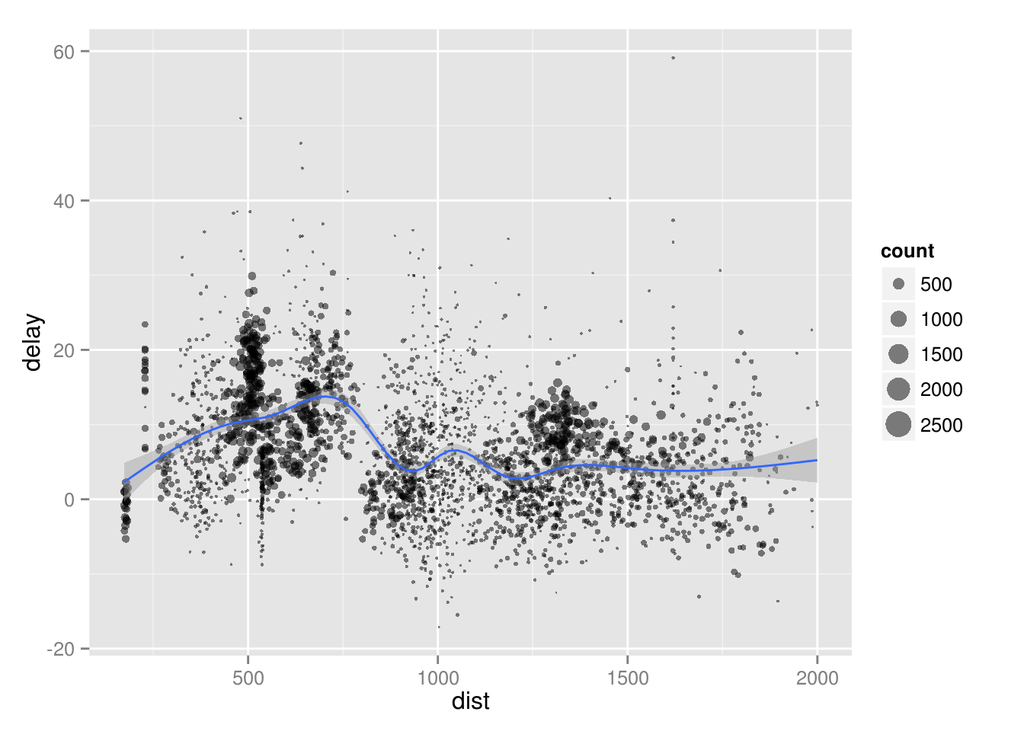

```r
planes <- group_by(flights, tailnum)
delay <- summarise(planes,
  count = n(),
  dist = mean(distance, na.rm = TRUE),
  delay = mean(arr_delay, na.rm = TRUE))
delay <- filter(delay, count > 20, dist < 2000)

# Интересно, на сколько зависит
# средняя задержка от средней дальности полёта
ggplot(delay, aes(dist, delay)) +
  geom_point(aes(size = count), alpha = 1/2) +
  geom_smooth() +
  scale_size_area()
```

Вы использовали `summarise()` с функциями агрегирования, получающими вектор значений и возвращающими скалярное значение. Множество таких функций есть в базовой среде R, например `min()`, `max()`, `mean()`, `sum()`, `sd()`, `median()` и `IQR()`. `dplyr` предлагает ещё несколько полезных:

- `n()`: количество наблюдений в группе,
- `n_distinct(x)`: количество наблюдений с уникальным значением переменной x.
- `first(x)`, `last(x)` и `nth(x, n)` – работают подобно `x[1]`, `x[length(x)]`, и `x[n]`, но дают больше контроля над результатом если значение не может быть получено.

Например, мы можем использовать их чтобы найти количество самолётов и количество вылетов во все возможные пункты назначения:

```r
destinations <- group_by(flights, dest)
summarise(destinations,
  planes = n_distinct(tailnum),
  flights = n()
)
```

```
#> Source: local data frame [105 x 3]
#>
#>    dest planes flights
#> 1   ABQ    108     254
#> 2   ACK     58     265
#> 3   ALB    172     439
#> 4   ANC      6       8
#> ..  ...    ...     ...
```

Также вы можете применить собственную функцию. Для повышения производительности многие функции `dplyr` написаны на `C++`. Если вы хотите использовать собственную функцию на `C++` обратите внимание на соответствующее руководство[*](http://cran.rstudio.com/web/packages/dplyr/vignettes/hybrid-evaluation.html) для уточнения деталей.

При группировке по нескольким переменным вы можете также получить “послойные” итоги для каждого уровня в отдельности и по очереди. Этот приём позволяет кумулятивно получать свёртку набора данных:

```r
daily <- group_by(flights, year, month, day)
(per_day   <- summarise(daily, flights = n()))
```

```
#> Source: local data frame [365 x 4]
#> Groups: year, month
#>
#>    year month day flights
#> 1  2013     1   1     842
#> 2  2013     1   2     943
#> 3  2013     1   3     914
#> 4  2013     1   4     915
#> ..  ...   ... ...     ...
```

```r
(per_month <- summarise(per_day, flights = sum(flights)))
```

```
#> Source: local data frame [12 x 3]
#> Groups: year
#>
#>    year month flights
#> 1  2013     1   27004
#> 2  2013     2   24951
#> 3  2013     3   28834
#> 4  2013     4   28330
#> ..  ...   ...     ...
```

```r
(per_year  <- summarise(per_month, flights = sum(flights)))
```

```
#> Source: local data frame [1 x 2]
#>
#>   year flights
#> 1 2013  336776
```

Однако необходимо проявлять осторожность при таком методе получения итогов: он подойдёт для сумм и количеств, но нужно задуматься при использовании средних и дисперсий, и уж точно не применять с медианой.

# Последовательные (конвейерные) манипуляции

API (легендарный мощный ЭПиАй) `dplyr` функционален, в том смысле, что вызовы функций не имеют побочных эффектов, и вы должны сами сохранять результаты. Это обстоятельство не способствует написанию элегантного кода если вам нужно выполнить множество операций подряд. Вы, конечно, можете выполнять их шаг за шагом:

```r
a1 <- group_by(flights, year, month, day)
a2 <- select(a1, arr_delay, dep_delay)
a3 <- summarise(a2,
  arr = mean(arr_delay, na.rm = TRUE),
  dep = mean(dep_delay, na.rm = TRUE))
a4 <- filter(a3, arr > 30 | dep > 30)
```

Или, если вы не желаете сохранять промежуточные результаты, можно передавать вызовы функций как аргументы, вкладывая один в другой:

```r
filter(
  summarise(
    select(
      group_by(flights, year, month, day),
      arr_delay, dep_delay
    ),
    arr = mean(arr_delay, na.rm = TRUE),
    dep = mean(dep_delay, na.rm = TRUE)
  ),
  arr > 30 | dep > 30
)
```

```
#> Source: local data frame [49 x 5]
#> Groups: year, month
#>
#>    year month day      arr      dep
#> 1  2013     1  16 34.24736 24.61287
#> 2  2013     1  31 32.60285 28.65836
#> 3  2013     2  11 36.29009 39.07360
#> 4  2013     2  27 31.25249 37.76327
#> ..  ...   ... ...      ...      ...
```

Что создаёт сложности с чтением, так как порядок выполнения начинается из середины выражения и аргументы отдаляются от текста вызова функции. Чтобы обойти это проблему `dplyr` использует оператор `%>%`. `x %>% f(y)` преобразуется в `f(x, y)`, что можно использовать для преобразования кода вызовов в удобный для чтения слева направо, сверху вниз:

```r
flights %>%
  group_by(year, month, day) %>%
  select(arr_delay, dep_delay) %>%
  summarise(
    arr = mean(arr_delay, na.rm = TRUE),
    dep = mean(dep_delay, na.rm = TRUE)
  ) %>%
  filter(arr > 30 | dep > 30)
```

# Другие источники данных

Также как с `data.frame`, `dplyr` может работать с данными представленными другими способами, такими как `data tables`, базы данных и многомерные массивы.

## Data table

`dplyr` также предлагает все перечисленные методы манипулирования данным и для объектов типа `data.tables`[*](http://datatable.r-forge.r-project.org/), вы просто должны заменить набор данных на `data.table`.

Преимущества при использовании `data.tables` следующие:

- В большинстве случаев `data.tables` изолирует вас от данных непосредственно, и защищает их таким образом от непреднамеренного изменения.
- Вместо изощрённого использования встроенного оператора `[`, предлагается множество относительно простых методов.

## Базы данных

`dplyr` позволяет использовать удалённые базы данных так же как `data.frame`. Избавляя таким образом от необходимости постоянно переключать мышление между языками. Для уточнения деталей необходимо обратиться к соответствующему руководству[*](http://cran.rstudio.com/web/packages/dplyr/vignettes/databases.html).

По сравнению с другим вариантами использования баз данных: * скрывается, на сколько это возможно, факт использования удалённой базы данных * исчезает необходимость изучать какой-либо диалект sql (хотя это может быть полезно!) * предоставляется прослойка между множеством различных реализаций интерфейсов баз данных.

## Многомерные массивы/кубы

`tbl_cube()` предлагает экспериментальный интерфейс к многомерным массивам или кубам (как OLAP-кубы) . Если вы используете подобное представление в R, пожалуйста, свяжитесь с автором чтобы он лучше понял ваши потребности.

# Сравнение с другими подходами

В сравнение со всеми существующими альтернативами, `dplyr`:

- абстрагирует от способа хранения данных, так что возможно использование одного и того же набора функций для манипулирования `data.frame`, `data.tables` и удалёнными базами данных. Это позволяет думать только о том что вы хотите сделать с данными, а не об устройстве хранилища данных
- предлагает продуманный метод `print()`, которые не распечатает случайно несколько страниц данных на экран (вдохновение было почерпнуто в `data.tables`).

В сравнении с функциями из основной поставки:

- `dplyr` намного более строен; функции имеют идентичный интерфейс, так что освоив одну вы разбираетесь и в других
- функции из базовой поставки стремятся обрабатывать векторы; `dplyr` концентрируется на наборах данных

В сравнении с `plyr`:

- `dplyr` намного намного быстрее
- предлагает более продуманный набор объединений(**?**)
- предлагает инструменты только для работы с `data.frame` (т.о. большая часть `dplyr` эквивалентна `ddply()` с добавлением некоторых функций, `do()` эквивалентна `dlply()`)

В сравнении с использованием виртуальных `data.frame`:

- виртуальный `data.frame` не предполагает что у вас есть данные, так что если необходимо выполнить `lm()` понадобится получить данные вручную
- виртуальный `data.frame` не предоставляет методов для агрегатных функций (т.е. `mean()` или `sum()`)